# 05 Plots

## Now for some fun

There is more to be said about data wrangling, and we will get back to it, but I want to create some plots first. Plots are fun because they give you nice and colourful results, and they are a very important tool for inspecting your data and getting an intuition for it. While base `R` has a plotting function, the `tidyverse`’s `ggplot2` is what is partly responsible fpr `R`’s fame.

`ggplot2` is based on the [“Grammar of Graphics” by Leland Wilkinson](https://www.springer.com/de/book/9780387245447), a framework for good data visualisation in data science. In a way, `ggplot2` has a grammar of its own, which is something new for us. But don’t worry, it all makes sense.

First, we need some data. I want to use the opportunity to show you how you would preprocess your data in a separate file, and then use it in you R Markdown file. We want to set up a little pre-processing file for our nerd data. To achieve this, we will go though the file `04_data_wrangling.Rmd` and copy-paste the bits of code that we need in order to get the raw data ready to be plotted.

```r
library(tidyverse)
source("05_nerd_preprocessing.R")
```

One basic plot that you will frequently need is a histrogram. It’s a good way to quickly inspect the distribution of your data. Below, you see how a simple histogram for the participant age works. The concept is pretty simple: We pipe our data, `nerd_red` into the ggplot function. Within the function, we use the `aes()` function, which stands for “aesthetics”. The aesthetic function is used to tell `ggplot` all the information that is related to the data (as opposed to things that have nothing to do with the data, e.g. overall plot colour). It will make more sense once we see which things belong into `aes()` and which things belong outside of it. Unsurprisingly, the argument `x` is what we want to put on the x-axis, which is the age of our participants in this case. Lastly, we tell ggplot to make a histogram. Ggplot uses different “geoms”, which you can imagine as different “geometric” plot shapes. Other geoms are for example `geom_point`, `geom_bar` or `geom_boxplot`. You can probably guess what they do. The special thing is that we don’t use a pipe to add the histogram, but a plus sign. That is because ggplots work in “layers”. You might have used an image maniplation program (or something like PowerPoint) that followed the same logic: When you created an image, some elements were behind/in front of each other. In ggplot, that’s the same. We have the plot background as first layer, and then there’s our histrogram on top of that.

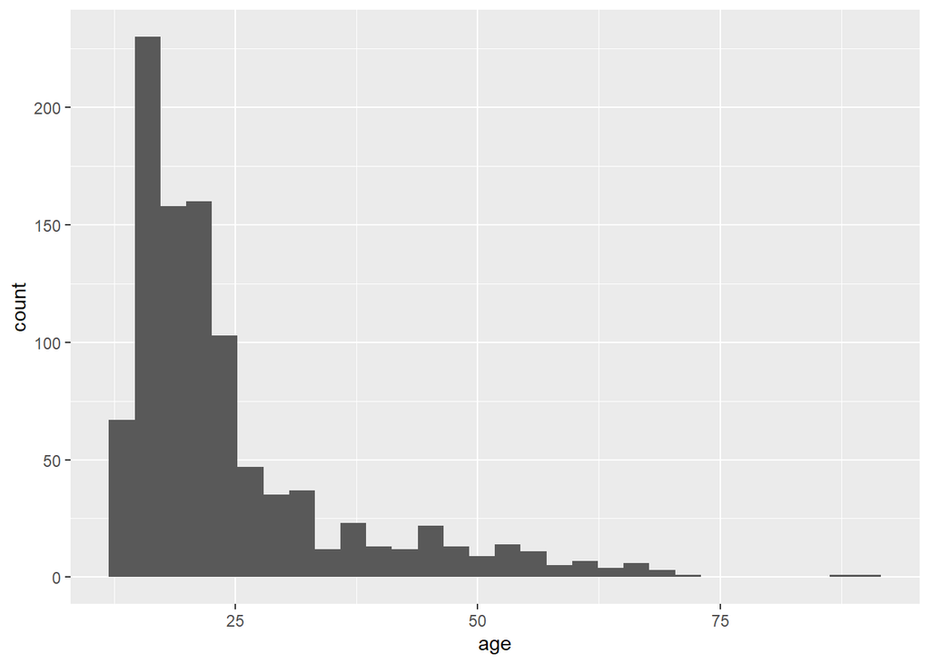

```r
nerd_red %>%
  ggplot(aes(x = age)) +
  geom_histogram()
```

We can observe the layered structure by leaving out the histogram layer. Here, we can see that ggplot still drew the plot background for us. It also labelled the x-axis with “age”, because it knows that our age data will go there. Furthermore, it picked a sensible scale for the axis, because it knows the minimum/maximum of our data and can figure out the range it will need to plot. However, no data is plotted, and there is no y-axis. We did not provide any information for the y-axis. In our previous plot, `geom_histogram` automatically counted how many participants were in each age bin, and based the y-axis on that.

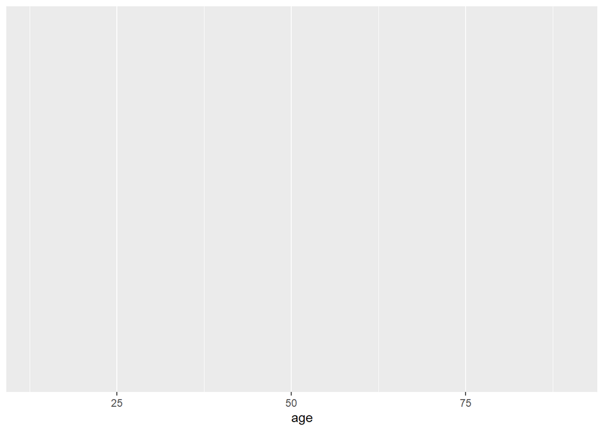

```r
nerd_red %>%
  ggplot(aes(x = age))
```

Let’s check out a different geom. Try `geom_boxplot()`. It looks a bit weird - what might be the problem here?

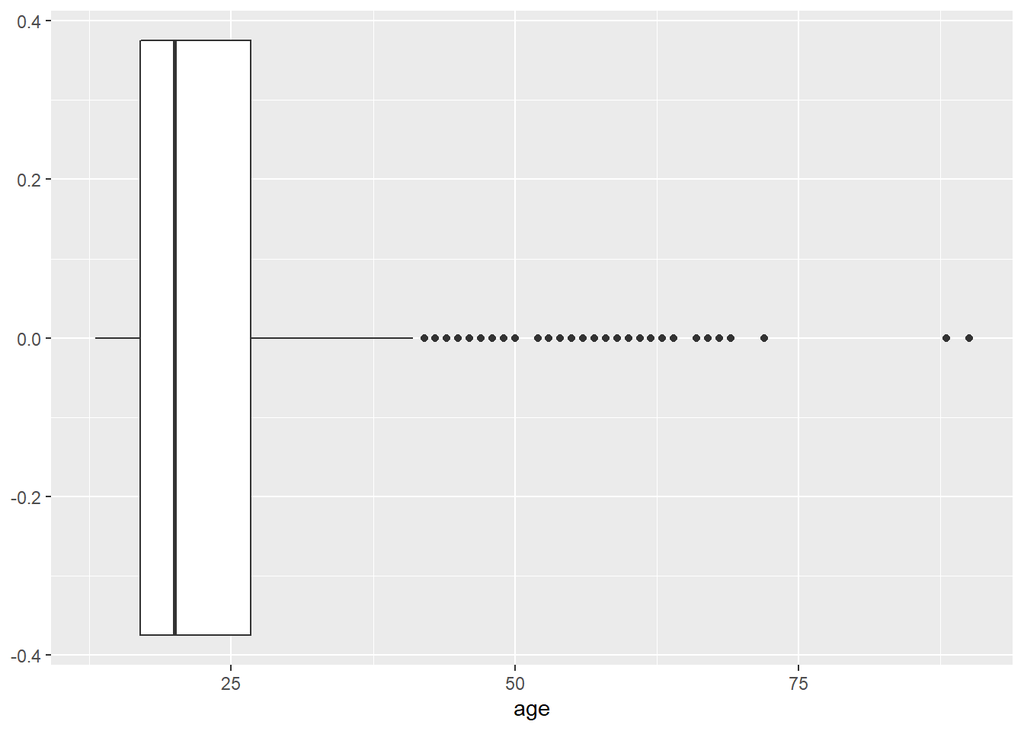

```r
# TAKE OUT FOR THE COURSE!
nerd_red %>%
  ggplot(aes(x = age)) +
  geom_boxplot()
```

The plot will look much better with a different orientation, i.e. the data on the y-axis.

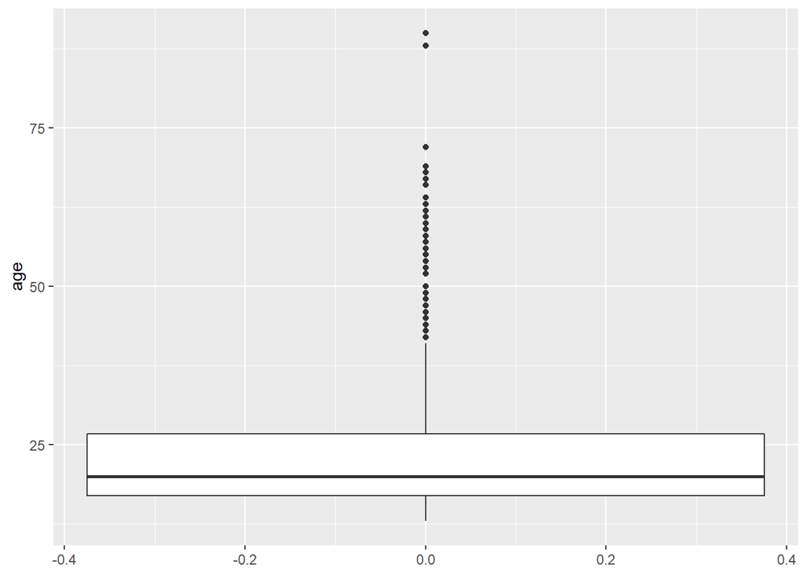

```r
# TAKE OUT FOR THE COURSE!
nerd_red %>%
  ggplot(aes(y = age)) +
  geom_boxplot()
```

But still, the x-axis looks weird. Here’s how we can fix that. There’s still that nastly little x as axis label - we’ll talk about how to get rid of that later.

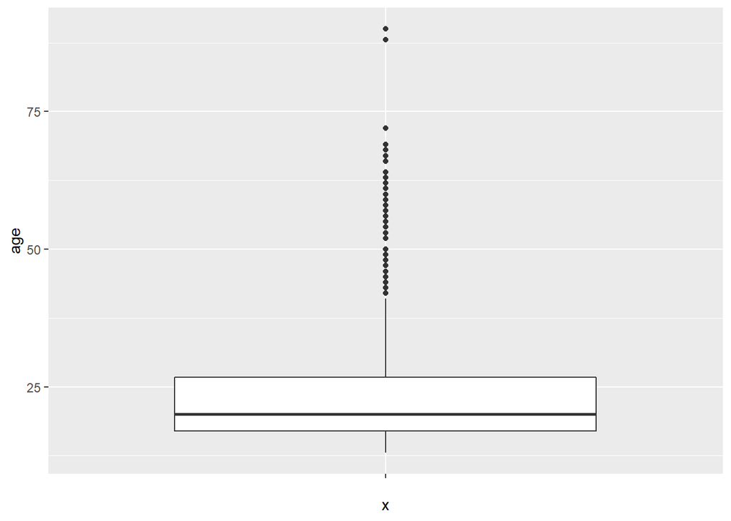

```r
# TAKE OUT FOR THE COURSE!
nerd_red %>%
  ggplot(aes(y = age, x = "")) +
  geom_boxplot()
```

For now, let’s try another geom. How about a good old scatter plot? However, this requires information about both x and y, which makes sense. What do we want to plot on next to age? Maybe the nerd score?

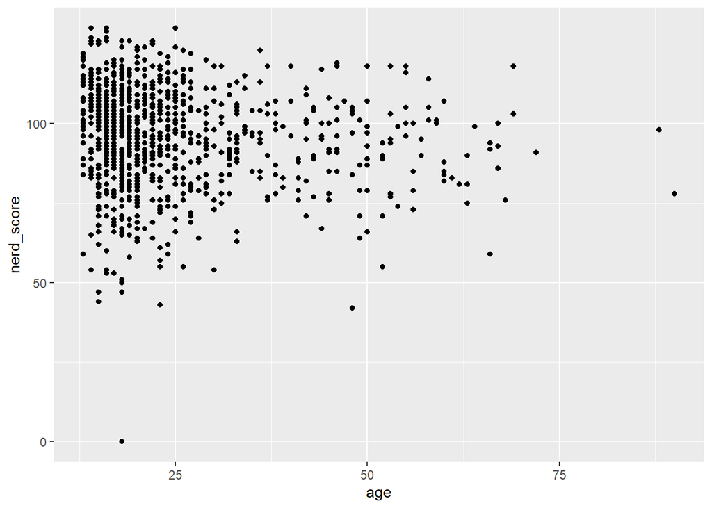

```r
# TAKE OUT FOR THE COURSE!
nerd_red %>%
  ggplot(aes(x = age, y = nerd_score)) +
  geom_point()
```

How about adding a line to the data, indicating how age and nerd score are associated with each other? The corresponding geom is called `geom_smooth`.

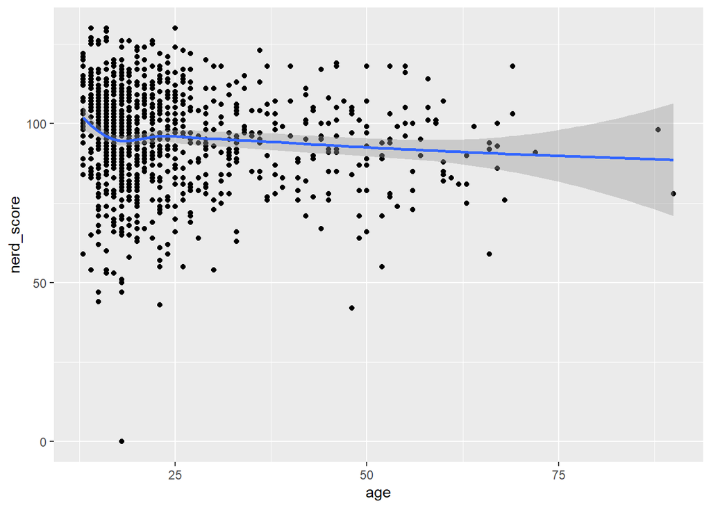

```r
# TAKE OUT FOR THE COURSE!
nerd_red %>%
  ggplot(aes(x = age, y = nerd_score)) +
  geom_point() +
  geom_smooth()
```

The default method for `geom_smooth`, as `R` informs us, is “loess”. We can also have a plain linear regression line, which we achieve like this:

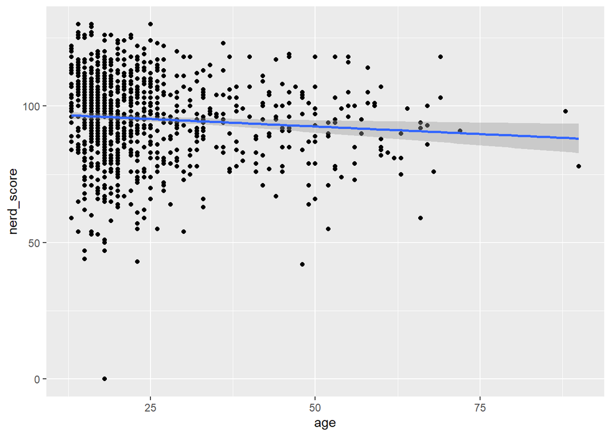

```r
# TAKE OUT FOR THE COURSE!
nerd_red %>%
  ggplot(aes(x = age, y = nerd_score)) +
  geom_point() +
  geom_smooth(method = "lm")
```

We can also split our plot by another variable, e.g. gender. Gender is a property of our data, so it also goes into the `aes()` function.

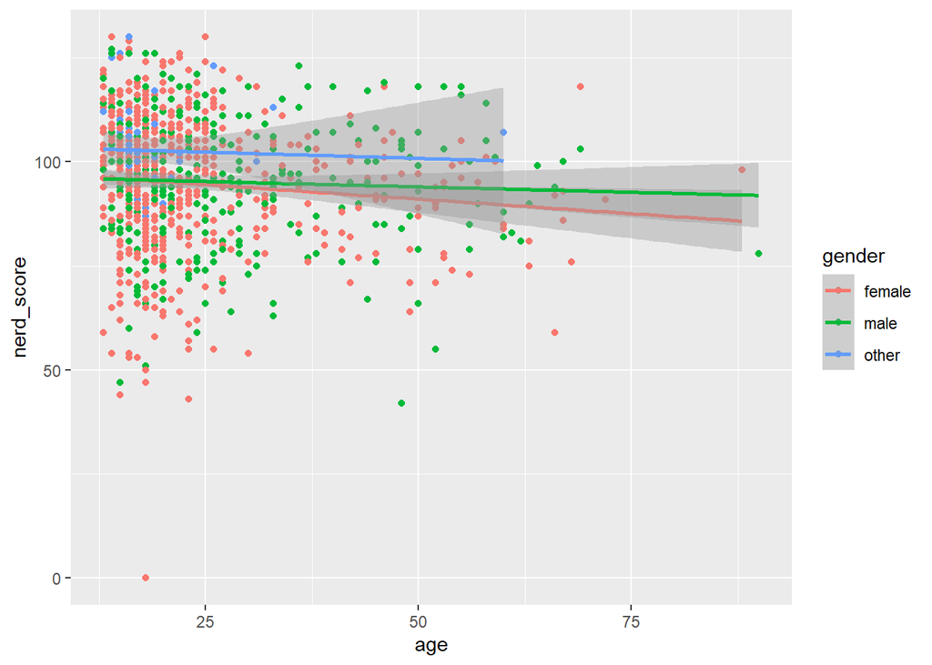

```r
nerd_red %>%
  ggplot(aes(x = age, y = nerd_score, colour = gender)) +
  geom_point() +
  geom_smooth(method = "lm")
```

## Customise things

This is all fun and games, but the plot is not as nice as it could be. We want to customise it a little bit. For example, the text on the y axis says “nerd_score”, because ggplot just put in the name of the column. We can change that in the following way:

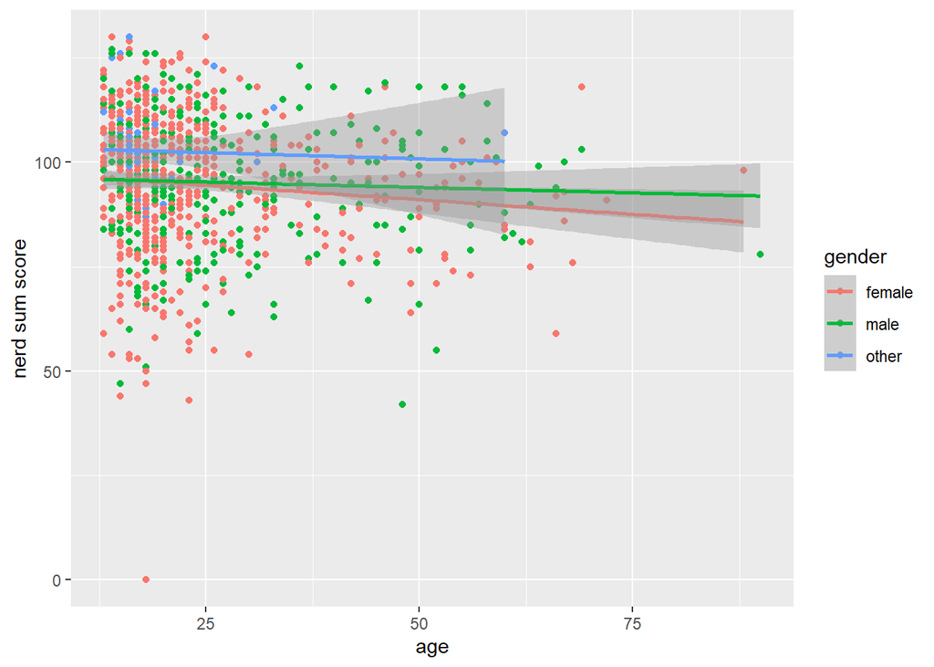

```r
nerd_red %>%
  ggplot(aes(x = age, y = nerd_score, colour = gender)) +
  geom_point() +
  geom_smooth(method = "lm") +
  labs(y = "nerd sum score")
```

Next, let’s move the legend to the top of the plot. Using `theme()`, we can control **a lot** of things in our plot, like font sizes, whether there should be grid lines or not and much, much more.

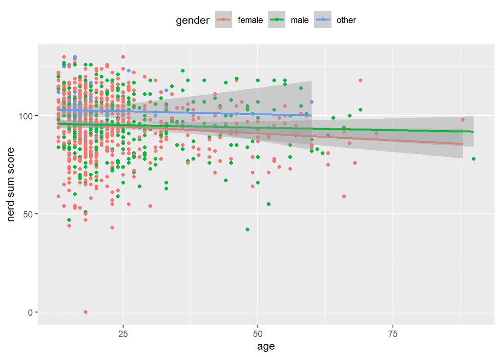

```r
nerd_red %>%
  ggplot(aes(x = age, y = nerd_score, colour = gender)) +
  geom_point() +
  geom_smooth(method = "lm") +
  labs(y = "nerd sum score") +
  theme(legend.position = "top")
```

This grey plot grid is something ggplot is very famous for. However, it might not be the most beautiful and modern plotting option. You can either set up a completely custom theme using the `theme()` function, or you can use one of the many default themes, for example:

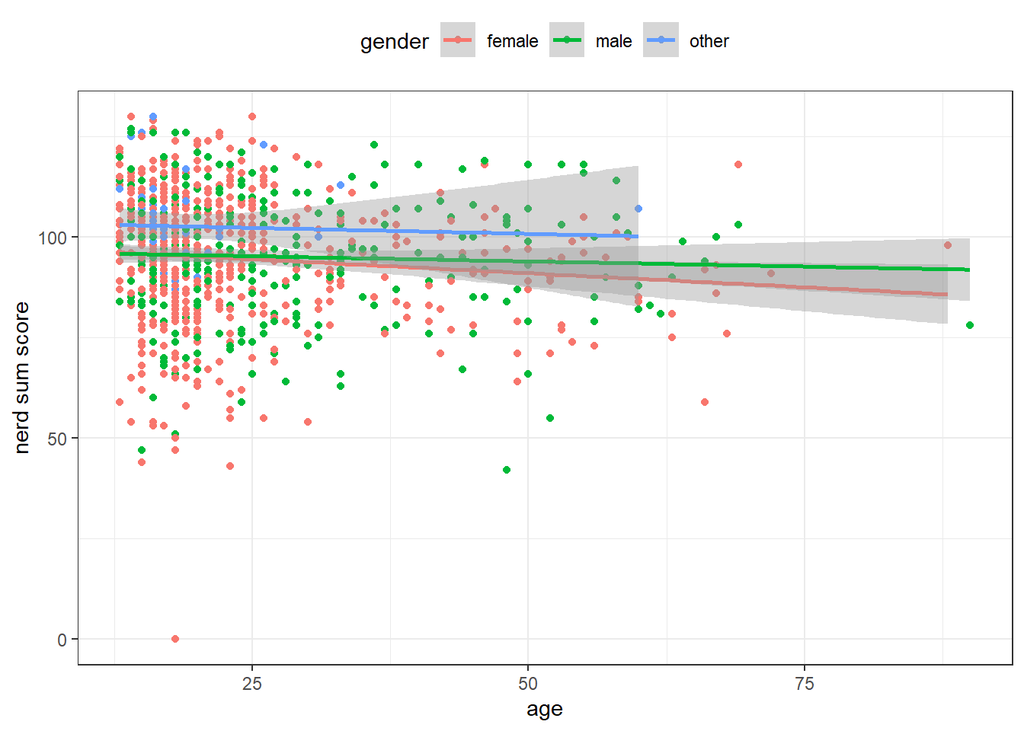

```r
nerd_red %>%
  ggplot(aes(x = age, y = nerd_score, colour = gender)) +
  geom_point() +
  geom_smooth(method = "lm") +
  labs(y = "nerd sum score") +
  theme_bw() +
  theme(legend.position = "top")
```

Much better. How about more fine-grained steps on the x and y axis? One quick way to set up the breaks on a plot axis is the function `seq()`. It generates a sequence of numbers. You give it the start point, the end point, and the stepsize:

```r
seq(1, 10, 2)
```

```
## [1] 1 3 5 7 9
```

It is also possible not to give a step size, but the **number** of steps instead:

```r
seq(1, 10, length.out = 3)
```

```
## [1]  1.0  5.5 10.0
```

So, we can use `seq()` to adjust our axes like this:

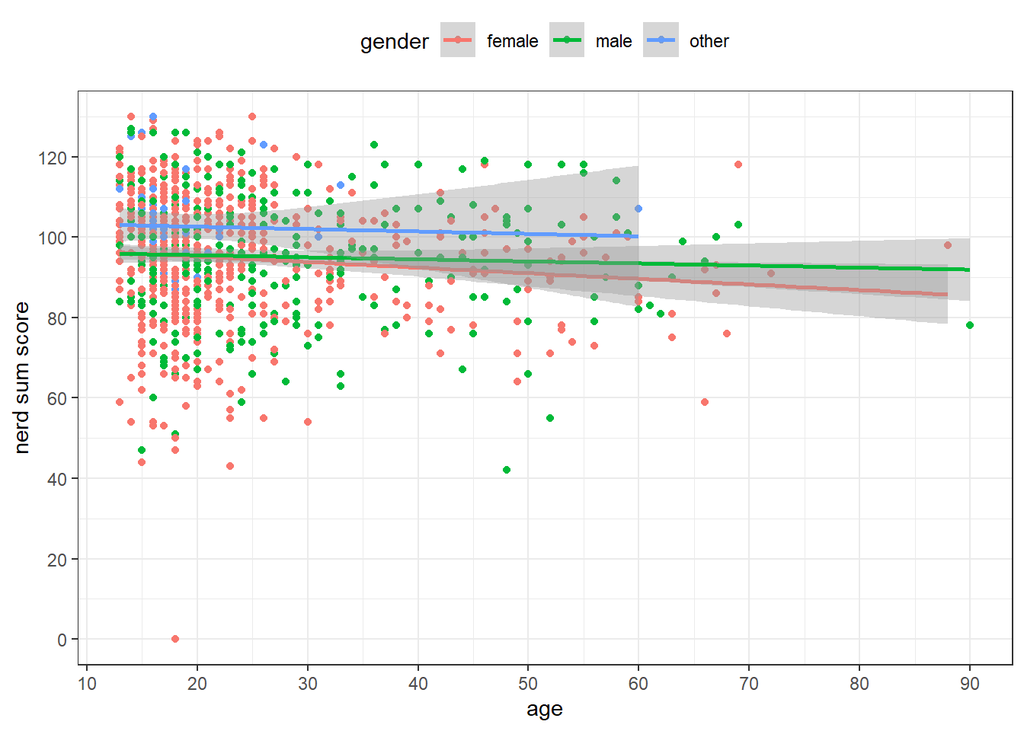

```r
nerd_red %>%
  ggplot(aes(x = age, y = nerd_score, colour = gender)) +
  geom_point() +
  geom_smooth(method = "lm") +
  labs(y = "nerd sum score") +

  scale_x_continuous(breaks = seq(10, 90, 10)) +
  scale_y_continuous(breaks = seq(0, 140, 20)) +

  theme_bw() +
  theme(legend.position = "top")
```